# 🌵 US Drought Monitor Archive

This repository provides a reproducible, archival-quality pipeline to download, validate, transform, and document weekly shapefiles from the [US Drought Monitor (USDM)](https://droughtmonitor.unl.edu). The archive is structured using the [BagIt 1.0 specification](https://tools.ietf.org/html/draft-kunze-bagit-14) and includes:

- Raw weekly shapefiles and text summaries
- Cleaned, validated spatial data in GeoParquet format
- Per-week ISO 19115-1 metadata in XML
- Geometry validation logs
- Weekly updating and manifest tracking

The goal of this repository is to draft a regulatory-grade archive of the US Drought Monitor that conforms with the *Foundations for Evidence-Based Policymaking Act of 2018* (“Evidence Act”, [Public Law 115–435](https://www.congress.gov/115/statute/STATUTE-132/STATUTE-132-Pg5529.pdf)), the *Geospatial Data Act of 2018* (enacted as part of [Public Law 115–254](https://www.congress.gov/115/statute/STATUTE-132/STATUTE-132-Pg3186.pdf)), and [Executive Order 14303, *Restoring Gold Standard Science*](https://www.federalregister.gov/documents/2025/05/29/2025-09802/restoring-gold-standard-science). Given the regulatory role played by the USDM (e.g., [7 CFR 1416.205](https://www.ecfr.gov/current/title-7/section-1416.205), [7 CFR 759.5](https://www.ecfr.gov/current/title-7/section-759.5)), it is essential that an authoritative, well-documented, persistent, and findable archive of the USDM be established by a Federal agency. This work seeks to create a framework for such an archive.

## 📈 About the US Drought Monitor (USDM)

The US Drought Monitor is a weekly map-based product that synthesizes multiple drought indicators into a single national assessment. It is produced by:

- National Drought Mitigation Center (NDMC)
- US Department of Agriculture (USDA)
- National Oceanic and Atmospheric Administration (NOAA)

Each weekly map represents a combination of data analysis and expert interpretation.

> **Note**: This archive is maintained by the Montana Climate Office, but all analytical authorship of the USDM drought maps belongs to the named USDM authors.

## 🧪 Analysis Pipeline

This R pipeline (`usdm.R`):

1. **Downloads** weekly USDM shapefiles and XML summaries.
2. **Validates** geometries using the [S2 Geometry Library](https://s2geometry.io/) via `sf::st_is_valid()`, and logs invalid features for review.
3. **Cleans and repairs** shapefile geometries and converts them to the [GeoParquet](https://geoparquet.org) format.
4. **Writes ISO 19115-1 metadata** for each weekly dataset using the `geometa` package.
5. **Builds a BagIt structure** with SHA-256 checksums to ensure archival integrity.

## 🗂 Directory Structure

The resulting BagIt-compliant archive includes:

```
repository-root/
  ├── LICENSE                 # License for the repository (MIT)
  ├── README.md               # Repository documentation (this file)
  ├── README.Rmd              # Repository documentation (RMarkdown)
  ├── usdm.R                  # Main R script to download, process, and archive USDM data
  ├── usdm.Rproj              # RStudio project file
  ├── usdm.html               # An HTML directory listing of the USDM Archive
  ├── usdm-manifest.json      # The directory listing of the USDM Archive
  └── usdm/                   # BagIt-compliant archive of USDM weekly data
    ├── bagit.txt               # BagIt version declaration
    ├── bag-info.txt            # Metadata about the bag archive
    ├── manifest-sha256.txt     # Checksums for integrity verification
    └── data/
      ├── raw/                    # Downloaded shapefiles (.zip)
      ├── summary/                # Weekly summary XML files
      ├── parquet/                # Cleaned spatial data (.parquet)
      ├── metadata/               # ISO 19115 metadata XML files
      └── quality/
        └── geometry_validation.csv  # Log of geometry validation issues
```

[interactive chart not shown]

## 🔁 Weekly Updating

The pipeline automatically determines the most recent USDM date available and:

- Only downloads new or modified files.
- Uses file checksums to avoid unnecessary re-processing.
- Appends new validation issues to a persistent quality log.

Use the `usdm()` function to process a specific date, or `usdm_get_dates()` to get all valid weekly dates.

## 🛠️ Dependencies

Key R packages used:

- `sf`, `terra`, `arrow`, `tidyverse`, `curl`
- `geometa` for ISO metadata
- `digest` for checksum computation

The script installs all required packages using the [`pak`](https://pak.r-lib.org) package.

## 📍 Quick Start: Visualize a Weekly USDM Map in R

This snippet shows how to load a weekly GeoParquet file from the archive and create a simple drought classification map using `sf` and `ggplot2`.

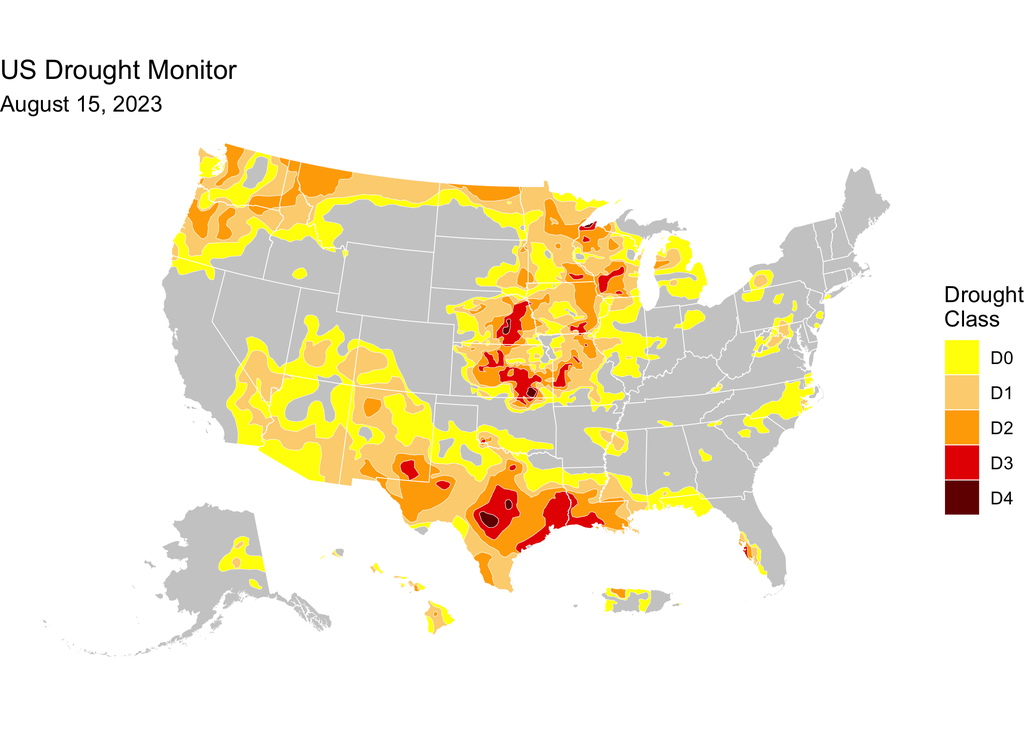

```r
# Load required libraries
library(arrow)
library(sf)
library(ggplot2) # For plotting
library(tigris)  # For state boundaries
library(rmapshaper) # For innerlines

# Read a weekly GeoParquet file as an sf object
# Use tigris::shift_geometry to shift and rescale Alaska, Hawaii, and Puerto Rico in a US-wide sf object
usdm_sf <-
  sf::read_sf("https://climate-smart-usda.github.io/usdm/usdm/data/parquet/USDM_2023-08-15.parquet") |>
  # tigris::shift_geometry only works consistently on POLYGON geometries, so coerce.
  sf::st_cast("POLYGON", warn = FALSE, do_split = TRUE) |> #
  tigris::shift_geometry()

states <-
  tigris::states(cb = TRUE,
                 resolution = "5m",
                 progress_bar = FALSE) |>
  dplyr::filter(
    !(NAME %in% c("Guam",
                  "American Samoa",
                  "United States Virgin Islands",
                  "Commonwealth of the Northern Mariana Islands"))
  ) |>
  sf::st_cast("POLYGON", warn = FALSE, do_split = TRUE) |>
  tigris::shift_geometry()

# Plot the map
ggplot(usdm_sf) +
  geom_sf(data = sf::st_union(states),
          fill = "grey80",
          color = NA) +
  geom_sf(aes(fill = usdm_class),
          color = "white",
          linewidth = 0.1) +
  geom_sf(data = rmapshaper::ms_innerlines(states),
          fill = NA,
          color = "white",
          linewidth = 0.2) +
  scale_fill_manual(
    values = c("#ffff00",
               "#fcd37f",
               "#ffaa00",
               "#e60000",
               "#730000"),
    drop = FALSE,
    name = "Drought\nClass") +
  labs(title = "US Drought Monitor",
       subtitle = "August 15, 2023") +
  theme_void()
```

## 📝 Citation & Attribution

**Citation format** (suggested):

> US Drought Monitor authors. *US Drought Monitor Weekly Maps*. Data curated and archived by R. Kyle Bocinsky, Montana Climate Office. Accessed via GitHub archive, YYYY. https://climate-smart-usda.github.io/usdm/

**Acknowledgments**:

- Map content by USDM authors.
- Data curation and archival structure by R. Kyle Bocinsky, Montana Climate Office, University of Montana.

## 📄 License

- **Raw USDM data** (NDMC): Public Domain (17 USC § 105)
- **Processed data & scripts**: © R. Kyle Bocinsky, released under [CC0](https://creativecommons.org/publicdomain/zero/1.0/) and MIT License as applicable

## ⚠️ Disclaimer

This dataset is archived for research and educational use only. The National Drought Mitigation Center currently hosts the US Drought Monitor. Please visit https://droughtmonitor.unl.edu.

## 👏 Acknowledgment

This project is part of:

**[*Enhancing Climate-smart Disaster Relief in FSA Programs*](https://www.ars.usda.gov/research/project/?accnNo=444612)**  
Supported by USDA OCE/OEEP and USDA Climate Hubs  
Prepared by the [Montana Climate Office](https://climate.umt.edu)

## 📬 Contact

**R. Kyle Bocinsky**  
Director of Climate Extension  
Montana Climate Office  
📧 kyle.bocinsky@umontana.edu  
🌐 https://climate.umt.edu